# R Notebook

```r
library(skimr)
```

Load the housing_prices.csv data set and undertake an initial exploration of the data. You will find details on the data set on the relevant Kaggle page

```r
houses <- read_csv("data/housing_prices.csv")
```

```r
houses %>%
  summary()
```

```
   longitude         latitude     housing_median_age  total_rooms    total_bedrooms     population      households     median_income
 Min.   :-124.3   Min.   :32.54   Min.   : 1.00      Min.   :    2   Min.   :   2.0   Min.   :    3   Min.   :   2.0   Min.   : 0.4999
 1st Qu.:-121.8   1st Qu.:33.93   1st Qu.:18.00      1st Qu.: 1438   1st Qu.: 297.0   1st Qu.:  796   1st Qu.: 282.0   1st Qu.: 2.5268
 Median :-118.5   Median :34.27   Median :28.00      Median : 2111   Median : 436.0   Median : 1179   Median : 411.0   Median : 3.4500
 Mean   :-119.6   Mean   :35.65   Mean   :28.39      Mean   : 2620   Mean   : 539.6   Mean   : 1441   Mean   : 501.2   Mean   : 3.6767
 3rd Qu.:-118.0   3rd Qu.:37.73   3rd Qu.:37.00      3rd Qu.: 3120   3rd Qu.: 648.0   3rd Qu.: 1746   3rd Qu.: 606.0   3rd Qu.: 4.5826
 Max.   :-114.3   Max.   :41.95   Max.   :52.00      Max.   :39320   Max.   :6445.0   Max.   :35682   Max.   :6082.0   Max.   :15.0001
                                                                     NA's   :200
 median_house_value ocean_proximity
 Min.   : 14999     Length:19675
 1st Qu.:116600     Class :character
 Median :173800     Mode  :character
 Mean   :192478
 3rd Qu.:248200
 Max.   :500000
```

Look at some of the ratios that could be made from the raw data These could help with creating a model

```r
house_features <- houses %>%
  mutate(rooms_per_house = total_rooms / households,
         bedrooms_per_house = total_bedrooms / households,
         rooms_per_capita = total_rooms / population,
         bedrooms_per_capita = total_bedrooms / population,
         houses_per_capita = households / population,
         prop_bedrooms = total_bedrooms / total_rooms)

house_features %>%
  select(rooms_per_house:prop_bedrooms) %>%
  skim()
```

```
── Data Summary ────────────────────────
                           Values
Name                       Piped data
Number of rows             19675
Number of columns          6
_______________________
Column type frequency:
  numeric                  6
________________________
Group variables            None
```

|  | skim_variable | n_missing | complete_rate | mean | sd | p0 | p25 | p50 | p75 | p100 | hist |
| --- | --- | --- | --- | --- | --- | --- | --- | --- | --- | --- | --- |
| 1 | rooms_per_house | 0 | 1.0000000 | 5.3609011 | 2.29253818 | 0.8461538462 | 4.4145675 | 5.1843220 | 5.9706767 | 132.533333 | ▇▁▁▁▁ |
| 2 | bedrooms_per_house | 200 | 0.9898348 | 1.0970175 | 0.45393339 | 0.3333333333 | 1.0058881 | 1.0487805 | 1.0994620 | 34.066667 | ▇▁▁▁▁ |
| 3 | rooms_per_capita | 0 | 1.0000000 | 1.9393782 | 1.10014418 | 0.0025469169 | 1.4991141 | 1.9117148 | 2.2492904 | 55.222222 | ▇▁▁▁▁ |
| 4 | bedrooms_per_capita | 200 | 0.9898348 | 0.4003404 | 0.23841768 | 0.0006702413 | 0.3135992 | 0.3699187 | 0.4403794 | 14.194444 | ▇▁▁▁▁ |
| 5 | houses_per_capita | 0 | 1.0000000 | 0.3614741 | 0.09196174 | 0.0008042895 | 0.3025816 | 0.3524684 | 0.4089167 | 1.444444 | ▂▇▁▁▁ |
| 6 | prop_bedrooms | 200 | 0.9898348 | 0.2149754 | 0.05693687 | 0.1000000000 | 0.1776552 | 0.2045827 | 0.2409499 | 1.000000 | ▇▁▁▁▁ |

We expect the total_rooms of houses to be strongly correlated with total_bedrooms. Use ggpairs() to investigate correlations between these two variables.

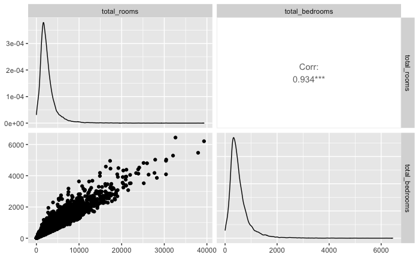

```r
houses %>%
  select(total_rooms, total_bedrooms) %>%
  ggpairs()
```

So, we do find significant correlations. Let’s drop total_bedrooms from the dataset, and use only total_rooms going forward.

[output not shown]

[output cut: 990 more lines]

We are interested in developing a regression model for the median_house_value of a house in terms of the possible predictor variables in the dataset.

Use ggpairs() to investigate correlations between median_house_value and the predictors (this may take a while to run, don’t worry, make coffee or something).

[output not shown]

[output cut: 34 more lines]

[output not shown]

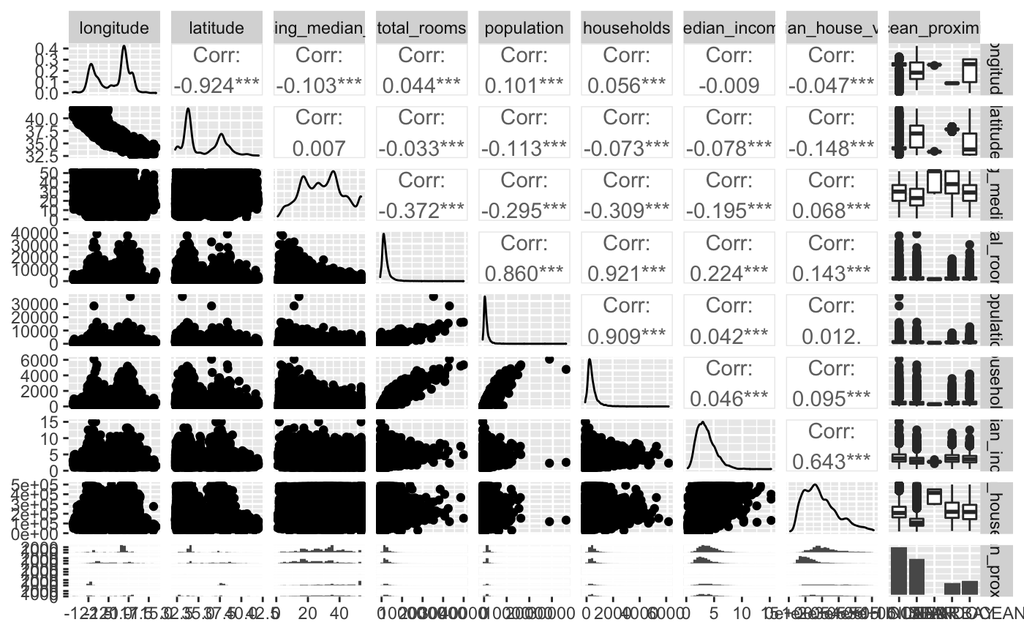

```r
houses %>%
  ggpairs()
```

updated ggpairs

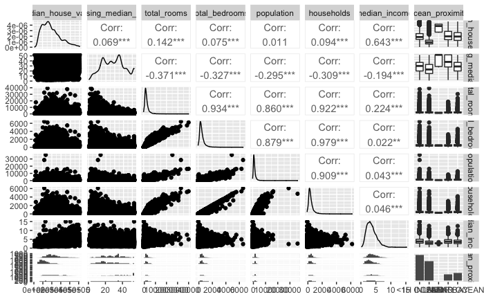

```r
house_features %>%
  select(-c(longitude, latitude, rooms_per_house:prop_bedrooms)) %>%
  select(median_house_value, everything()) %>% # use this to put median_house_value first in plots
  ggpairs(progress = FALSE)
ggsave("ggpairs1.png",
       width = 20,
       height = 12)
```

ggpairs with new variables created above

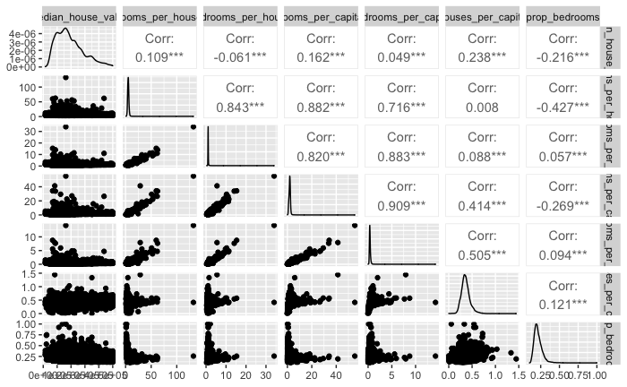

```r
house_features <- house_features %>%
  filter(!is.na(total_bedrooms))

house_features %>%
  select(median_house_value, rooms_per_house:prop_bedrooms) %>%
  select(median_house_value, everything()) %>% # use this to put median_house_value first in plots
  ggpairs(progress = FALSE)

ggsave("ggpairs2.png",
       width = 20,
       height = 12)
```

observations:

- median income very promising, high correlation (> 0.5)
- ocean proximity
  - explore levels
- houses per capita, prop bedrooms, rooms per house could all be useful